# (Ford GoBike System Data 2017)

## Investigation Overview

> In this project I performed an exploratory analysis on data provided by Ford GoBike, using Python visualization techniques. The goal is to find a spesific relationships between some variables that can provide the needed visualization between them .

## Dataset Overview

> This dataset includes information about individual rides made in a bike-sharing system covering the greater San Francisco Bay area.There are 519700 rows of trip trip in the dataset.

```python
# import all packages and set plots to be embedded inline
import numpy as np
import pandas as pd
import matplotlib.pyplot as plt
import seaborn as sb

%matplotlib inline

# suppress warnings from final output
import warnings
warnings.simplefilter("ignore")
```

```python
# load in the dataset into a pandas dataframe
fordgobike = pd.read_csv('2017-fordgobike-tripdata.csv')

#Change the dtypes.
fordgobike.start_time = pd.to_datetime(fordgobike.start_time)
fordgobike.end_time = pd.to_datetime(fordgobike.end_time)

fordgobike.bike_id = fordgobike.bike_id.astype(str)
fordgobike.user_type = fordgobike.user_type.astype('category')

# add some needed columns .
fordgobike['hour'] = fordgobike.start_time.dt.strftime('%H')
fordgobike['day'] = fordgobike.start_time.dt.strftime('%a')
fordgobike['month'] = fordgobike.start_time.dt.strftime('%b')
```

> Note that the above cells have been set as "Skip"-type slides. That means that when the notebook is rendered as http slides, those cells won't show up.

## (Visualization 1 : The highest trip day)

> From this bar chart, we can see that the highest trip day is Tuesday and wednesday , the lowest day is Sunday.

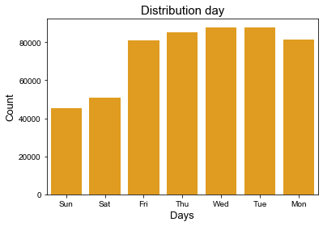

```python
# Find the highest trip day .
sb.countplot(data = fordgobike, x = 'day', color = 'orange')
sb.set(font_scale=0.90)
plt.title('Distribution day',size=15)
plt.xlabel('Days',size=13)
plt.ylabel('Count',size=13);
```

## (Visualization 2 : The relationship between duration and user type )

> From this plot we see the Customer type has longest duration than Subscriber.

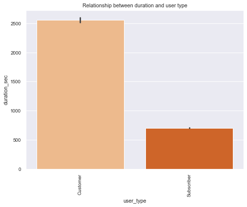

```python
#Find the Relationship between duration and user type .
plt.figure(figsize = [8,6])
sb.barplot(data = fordgobike, x = 'user_type', y = 'duration_sec', palette = 'Oranges')
plt.xticks(rotation=90)

plt.title('Relationship between duration and user type');
plt.show()
```

## (Visualization 3 : The relationship between trip duration and months)

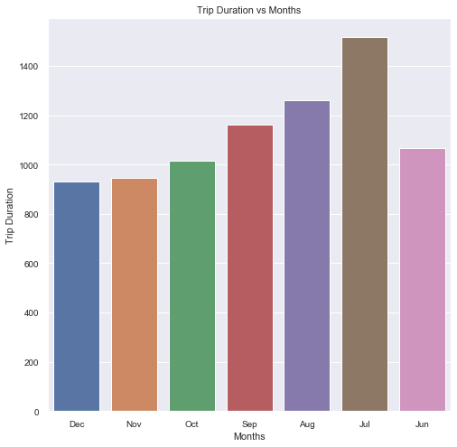

```python
# Find the relationship between trip duration and months.
plt.figure(figsize = [8,8])
plot= sb.barplot(data=fordgobike,x='month',y='duration_sec', ci=None)
plt.xlabel('Months')
plt.ylabel('Trip Duration')
plt.title('Trip Duration vs Months');
```

## (Visualization 4 : Trip duartion across user type in different days)

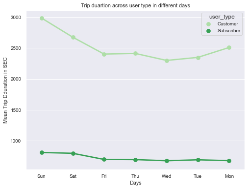

```python
fig = plt.figure(figsize = [8,6])
sb.pointplot(data = fordgobike, x = 'day', y = 'duration_sec', hue = 'user_type', palette = 'Greens', ci=None)

plt.title('Trip duartion across user type in different days')
plt.ylabel('Mean Trip Dduration in SEC')
plt.xlabel('Days')
plt.show();
```

## (Visualization 5: The avarge trip duration on months for each user type)

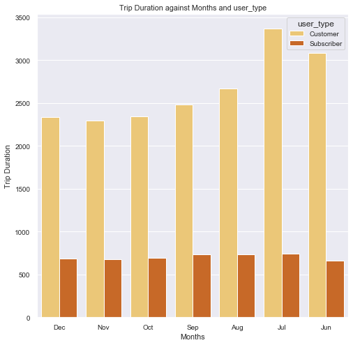

```python
# Find the avarge trip duration on months for each user type.
plt.figure(figsize = [8,8]);
axx = sb.barplot(data=fordgobike,x='month',y='duration_sec',hue='user_type' ,color=sb.color_palette()[0], palette='YlOrBr', ci=None);
plt.xlabel('Months');
plt.ylabel('Trip Duration');
plt.title('Trip Duration against Months and user_type');
```

> Once you're ready to finish your presentation, check your output by using nbconvert to export the notebook and set up a server for the slides. From the terminal or command line, use the following expression:

> > `jupyter nbconvert <file_name>.ipynb --to slides --post serve --template output_toggle`

> This should open a tab in your web browser where you can scroll through your presentation. Sub-slides can be accessed by pressing 'down' when viewing its parent slide. Make sure you remove all of the quote-formatted guide notes like this one before you finish your presentation!

```python
!jupyter nbconvert slide_deck_template.ipynb --to slides --post serve --template output_toggle
```

```
[NbConvertApp] Converting notebook slide_deck_template.ipynb to slides
[NbConvertApp] Writing 363013 bytes to slide_deck_template.slides.html
[NbConvertApp] Redirecting reveal.js requests to https://cdnjs.cloudflare.com/ajax/libs/reveal.js/3.5.0
Serving your slides at http://127.0.0.1:8000/slide_deck_template.slides.html
Use Control-C to stop this server
WARNING:tornado.access:404 GET /custom.css (127.0.0.1) 1.48ms
```